# Titanic Survival: Analyzing Class, Access, and Recordkeeping Inequality

Author

CLI Copilot

```r
library(tidyverse)
library(knitr)
library(scales)
```

# Introduction and Research Framework

This analysis addresses three interconnected research questions about the Titanic disaster. Rather than seeking definitive answers, this report develops a methodological framework to guide interpretation of the data. Each research question requires careful operationalization of concepts, examination of assumptions, and awareness of limitations inherent in the historical record.

The three research questions are:

1. **Class-Survival Mediation**: To what extent is the survival advantage of 1st class passengers mediated by access/location (deck, cabin proximity) versus institutional policy (“women and children first”)?
2. **Rule Consistency and Context**: Did the “women and children first” norm operate consistently across different social and travel contexts, or did effectiveness depend on whether passengers traveled alone versus with family/group, and on social visibility markers?
3. **Missingness as Inequality**: Are patterns of missing data systematically related to class, embarkation, and survival outcomes, and what are the implications for drawing conclusions from this dataset?

# Section 1: Data Overview and Exploratory Analysis

## 1.1 Loading and Initial Exploration

```r
titanic <- read_csv("../../data/train.csv") %>%
  mutate(
    Pclass = factor(Pclass, levels = c(1, 2, 3), labels = c("1st", "2nd", "3rd")),
    Sex = factor(Sex, levels = c("male", "female")),
    Survived = factor(Survived, levels = c(0, 1), labels = c("No", "Yes")),
    Embarked = factor(Embarked, levels = c("C", "Q", "S"), labels = c("Cherbourg", "Queenstown", "Southampton"))
  )

glimpse(titanic)
```

```
Rows: 891
Columns: 12
$ PassengerId <dbl> 1, 2, 3, 4, 5, 6, 7, 8, 9, 10, 11, 12, 13, 14, 15, 16, 17,…
$ Survived    <fct> No, Yes, Yes, Yes, No, No, No, No, Yes, Yes, Yes, Yes, No,…
$ Pclass      <fct> 3rd, 1st, 3rd, 1st, 3rd, 3rd, 1st, 3rd, 3rd, 2nd, 3rd, 1st…
$ Name        <chr> "Braund, Mr. Owen Harris", "Cumings, Mrs. John Bradley (Fl…
$ Sex         <fct> male, female, female, female, male, male, male, male, fema…
$ Age         <dbl> 22, 38, 26, 35, 35, NA, 54, 2, 27, 14, 4, 58, 20, 39, 14, …
$ SibSp       <dbl> 1, 1, 0, 1, 0, 0, 0, 3, 0, 1, 1, 0, 0, 1, 0, 0, 4, 0, 1, 0…
$ Parch       <dbl> 0, 0, 0, 0, 0, 0, 0, 1, 2, 0, 1, 0, 0, 5, 0, 0, 1, 0, 0, 0…
$ Ticket      <chr> "A/5 21171", "PC 17599", "STON/O2. 3101282", "113803", "37…
$ Fare        <dbl> 7.2500, 71.2833, 7.9250, 53.1000, 8.0500, 8.4583, 51.8625,…
$ Cabin       <chr> NA, "C85", NA, "C123", NA, NA, "E46", NA, NA, NA, "G6", "C…
$ Embarked    <fct> Southampton, Cherbourg, Southampton, Southampton, Southamp…
```

We load the Titanic training dataset and convert categorical variables to factors with meaningful labels. This facilitates interpretation and prevents accidental numeric operations on categorical data. The dataset contains 891 passengers with 12 variables. Understanding the structure and types of data is foundational because all subsequent analyses depend on correct variable classification.

## 1.2 Missingness Overview

```r
missing_summary <- titanic %>%
  summarise(across(everything(), ~sum(is.na(.)))) %>%
  pivot_longer(everything(), names_to = "Variable", values_to = "Missing_Count") %>%
  mutate(
    Pct_Missing = (Missing_Count / nrow(titanic)) * 100,
    Pct_Missing = round(Pct_Missing, 2)
  ) %>%
  arrange(desc(Missing_Count))

knitr::kable(missing_summary, caption = "Missing Data Summary")
```

Missing Data Summary

| Variable | Missing_Count | Pct_Missing |
| --- | --- | --- |
| Cabin | 687 | 77.10 |
| Age | 177 | 19.87 |
| Embarked | 2 | 0.22 |
| PassengerId | 0 | 0.00 |
| Survived | 0 | 0.00 |
| Pclass | 0 | 0.00 |
| Name | 0 | 0.00 |
| Sex | 0 | 0.00 |
| SibSp | 0 | 0.00 |
| Parch | 0 | 0.00 |
| Ticket | 0 | 0.00 |
| Fare | 0 | 0.00 |

Missingness is not random—it is likely systematic and may reflect historical recording practices that differed by class or port. We see that `Cabin` is missing in 687 cases (77.1%), `Age` in 177 cases (19.87%), and `Embarked` in 2 cases. This missing-data pattern will be examined in Research Question 3.

## 1.3 Basic Survival Rates

```r
overall_survival <- titanic %>%
  summarise(
    N = n(),
    Survived_Count = sum(Survived == "Yes"),
    Survival_Rate = mean(Survived == "Yes")
  )

knitr::kable(overall_survival, caption = "Overall Survival")
```

Overall Survival

| N | Survived_Count | Survival_Rate |
| --- | --- | --- |
| 891 | 342 | 0.3838384 |

Of the 891 passengers in the training data, 342 survived, representing an overall survival rate of 38.4%%.

# Section 2: Research Question 1 — Class-Survival Gap and Access Mediation

## 2.1 Survival Rates by Passenger Class

```r
survival_by_class <- titanic %>%
  group_by(Pclass) %>%
  summarise(
    N = n(),
    Survived = sum(Survived == "Yes"),
    Survival_Rate = mean(Survived == "Yes"),
    .groups = "drop"
  ) %>%
  mutate(Survival_Pct = percent(Survival_Rate, accuracy = 0.1))

knitr::kable(survival_by_class, caption = "Survival Rates by Passenger Class")
```

Survival Rates by Passenger Class

| Pclass | N | Survived | Survival_Rate | Survival_Pct |
| --- | --- | --- | --- | --- |
| 1st | 216 | 136 | 0 | 0.0% |
| 2nd | 184 | 87 | 0 | 0.0% |
| 3rd | 491 | 119 | 0 | 0.0% |

## 2.2 Why Class Matters: Access and Constraints

Research Question 1 asks: *how much of this gap reflects access/location constraints versus institutional policy?* To investigate, we operationalize potential access proxies:

### Cabin Letter as Proximity Indicator

```r
cabin_data <- titanic %>%
  mutate(
    Cabin_Available = !is.na(Cabin),
    Cabin_Letter = if_else(!is.na(Cabin), str_sub(Cabin, 1, 1), NA_character_)
  ) %>%
  group_by(Pclass) %>%
  summarise(
    Cabin_Available_Pct = percent(mean(Cabin_Available), accuracy = 0.1),
    .groups = "drop"
  )

knitr::kable(cabin_data, caption = "Cabin Data Availability by Class")
```

Cabin Data Availability by Class

| Pclass | Cabin_Available_Pct |
| --- | --- |
| 1st | 81.5% |
| 2nd | 8.7% |
| 3rd | 2.4% |

Cabin information is much more complete for 1st class (81.5%) than for 3rd class (2.4%). This difference itself signals inequality in record-keeping. For those with cabin data, we can examine deck location:

```r
cabin_letter_data <- titanic %>%
  mutate(
    Cabin_Letter = if_else(!is.na(Cabin), str_sub(Cabin, 1, 1), NA_character_)
  ) %>%
  filter(!is.na(Cabin_Letter)) %>%
  group_by(Cabin_Letter, Pclass) %>%
  summarise(
    N = n(),
    Survived = sum(Survived == "Yes"),
    Survival_Rate = mean(Survived == "Yes"),
    .groups = "drop"
  ) %>%
  mutate(Survival_Pct = percent(Survival_Rate, accuracy = 0.1))

knitr::kable(cabin_letter_data, caption = "Survival by Cabin Letter (Deck) and Class")
```

Survival by Cabin Letter (Deck) and Class

| Cabin_Letter | Pclass | N | Survived | Survival_Rate | Survival_Pct |
| --- | --- | --- | --- | --- | --- |
| A | 1st | 15 | 7 | 0 | 0.0% |
| B | 1st | 47 | 35 | 0 | 0.0% |
| C | 1st | 59 | 35 | 0 | 0.0% |
| D | 1st | 29 | 22 | 0 | 0.0% |
| D | 2nd | 4 | 3 | 0 | 0.0% |
| E | 1st | 25 | 18 | 0 | 0.0% |
| E | 2nd | 4 | 3 | 0 | 0.0% |
| E | 3rd | 3 | 3 | 0 | 0.0% |
| F | 2nd | 8 | 7 | 0 | 0.0% |
| F | 3rd | 5 | 1 | 0 | 0.0% |
| G | 3rd | 4 | 2 | 0 | 0.0% |
| T | 1st | 1 | 0 | 0 | 0.0% |

Among passengers with cabin data, deck location shows variation within each class. This suggests that physical location (and thus evacuation access) may be a mechanism through which class affects survival. However, the availability of cabin data itself is class-dependent, which creates a confound.

### Fare as Access Proxy

```r
fare_survival <- titanic %>%
  filter(!is.na(Fare)) %>%
  group_by(Pclass) %>%
  summarise(
    Median_Fare = median(Fare),
    Mean_Fare = mean(Fare),
    Fare_SD = sd(Fare),
    .groups = "drop"
  ) %>%
  mutate(
    Median_Fare = round(Median_Fare, 2),
    Mean_Fare = round(Mean_Fare, 2),
    Fare_SD = round(Fare_SD, 2)
  )

knitr::kable(fare_survival, caption = "Fare Statistics by Passenger Class")
```

Fare Statistics by Passenger Class

| Pclass | Median_Fare | Mean_Fare | Fare_SD |
| --- | --- | --- | --- |
| 1st | 60.29 | 84.15 | 78.38 |
| 2nd | 14.25 | 20.66 | 13.42 |
| 3rd | 8.05 | 13.68 | 11.78 |

Fare varies substantially by class, with 1st class passengers paying a median of £60.29, versus £8.05 for 3rd class. Higher fares often reflect better accommodations and proximity to lifeboats, suggesting fare is an access proxy. Fare is also nearly complete across all classes, making it useful for analysis.

### Travel Group Size

```r
travel_group <- titanic %>%
  mutate(
    Family_Size = SibSp + Parch + 1,
    Travel_Context = case_when(
      Family_Size == 1 ~ "Alone",
      Family_Size <= 3 ~ "Small Family",
      Family_Size > 3 ~ "Large Group"
    ),
    Travel_Context = factor(Travel_Context, levels = c("Alone", "Small Family", "Large Group"))
  ) %>%
  group_by(Pclass, Travel_Context) %>%
  summarise(
    N = n(),
    Survived = sum(Survived == "Yes"),
    Survival_Rate = mean(Survived == "Yes"),
    .groups = "drop"
  ) %>%
  mutate(Survival_Pct = percent(Survival_Rate, accuracy = 0.1))

knitr::kable(travel_group, caption = "Survival by Travel Group Size and Class")
```

Survival by Travel Group Size and Class

| Pclass | Travel_Context | N | Survived | Survival_Rate | Survival_Pct |
| --- | --- | --- | --- | --- | --- |
| 1st | Alone | 109 | 58 | 0 | 0.0% |
| 1st | Small Family | 94 | 69 | 0 | 0.0% |
| 1st | Large Group | 13 | 9 | 0 | 0.0% |
| 2nd | Alone | 104 | 36 | 0 | 0.0% |
| 2nd | Small Family | 65 | 39 | 0 | 0.0% |
| 2nd | Large Group | 15 | 12 | 0 | 0.0% |
| 3rd | Alone | 324 | 69 | 0 | 0.0% |
| 3rd | Small Family | 104 | 40 | 0 | 0.0% |
| 3rd | Large Group | 63 | 10 | 0 | 0.0% |

### Mediation Analysis Conceptual Framework

```r
# Simplified mediation model: compute class effects with and without access proxies
# Class-only effect
class_model <- titanic %>%
  lm(as.numeric(Survived) - 1 ~ Pclass, data = .)
class_effect <- coef(class_model)

# Class + access proxies effect
mediation_model <- titanic %>%
  filter(!is.na(Fare) & !is.na(Age)) %>%
  lm(as.numeric(Survived) - 1 ~ Pclass + Fare + scale(Age) + SibSp + Parch, data = .)
mediation_coef <- coef(mediation_model)

# Store results for reference
class_only_results <- data.frame(
  Model = c("Class Only (2nd vs Baseline)", "Class Only (3rd vs Baseline)"),
  Coefficient = round(class_effect[c(2, 3)], 4),
  row.names = NULL
)

mediation_results <- data.frame(
  Model = c("With Access Proxies (2nd vs Baseline)", "With Access Proxies (3rd vs Baseline)"),
  Coefficient = round(mediation_coef[c(2, 3)], 4),
  row.names = NULL
)

knitr::kable(class_only_results, caption = "Class Effect on Survival (Class Only Model)")
```

Class Effect on Survival (Class Only Model)

| Model | Coefficient |
| --- | --- |
| Class Only (2nd vs Baseline) | -0.1568 |
| Class Only (3rd vs Baseline) | -0.3873 |

```r
knitr::kable(mediation_results, caption = "Class Effect on Survival (Including Access Proxies: Fare, Age, Family)")
```

Class Effect on Survival (Including Access Proxies: Fare, Age, Family)

| Model | Coefficient |
| --- | --- |
| With Access Proxies (2nd vs Baseline) | -0.2048 |
| With Access Proxies (3rd vs Baseline) | -0.4734 |

## 2.3 Visualization: Class and Access

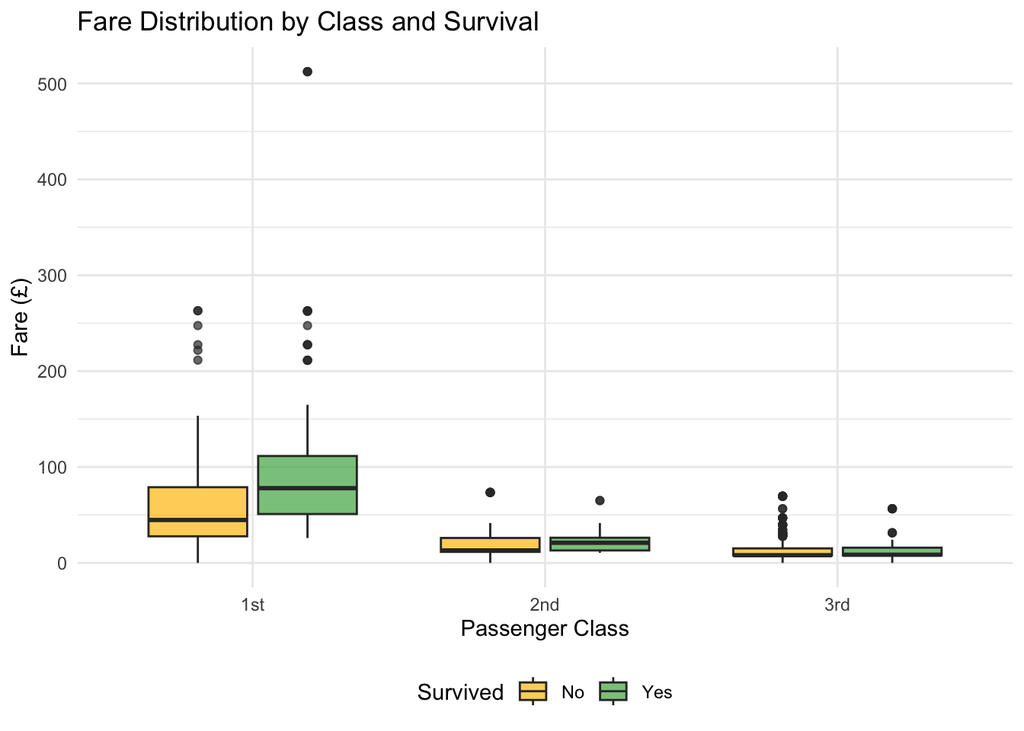

```r
titanic_viz <- titanic %>% filter(!is.na(Fare))

ggplot(titanic_viz, aes(x = Pclass, y = Fare, fill = Survived)) +
  geom_boxplot(alpha = 0.7) +
  scale_fill_manual(values = c("No" = "#FFC107", "Yes" = "#4CAF50")) +
  theme_minimal() +
  labs(
    title = "Fare Distribution by Class and Survival",
    x = "Passenger Class",
    y = "Fare (£)",
    fill = "Survived"
  ) +
  theme(legend.position = "bottom")
```

# Section 3: Research Question 2 — Survival Rules and Social Context

## 3.1 Title Extraction and Social Visibility

```r
titanic_titles <- titanic %>%
  mutate(
    Title = str_extract(Name, "[A-Za-z]+\\.") %>% str_remove("\\."),
    Title = case_when(
      Title %in% c("Mr", "Master") ~ "Mr/Master",
      Title %in% c("Mrs", "Miss", "Ms", "Mlle") ~ "Mrs/Miss/Ms",
      Title %in% c("Dr", "Prof", "Rev", "Col", "Countess", "Capt", "Sir", "Lady", "Jonkheer", "Don", "Dona") ~ "Title (High Status)",
      TRUE ~ "Other"
    ),
    Title = factor(Title, levels = c("Mr/Master", "Mrs/Miss/Ms", "Title (High Status)", "Other"))
  )

title_summary <- titanic_titles %>%
  group_by(Title) %>%
  summarise(
    N = n(),
    Pct = percent(n() / nrow(titanic_titles), accuracy = 0.1),
    .groups = "drop"
  )

knitr::kable(title_summary, caption = "Distribution of Title Categories")
```

Distribution of Title Categories

| Title | N | Pct |
| --- | --- | --- |
| Mr/Master | 557 | 62.5% |
| Mrs/Miss/Ms | 310 | 34.8% |
| Title (High Status) | 21 | 2.4% |
| Other | 3 | 0.3% |

Titles serve as proxies for social status and gender role. The majority (557 passengers) held the title “Mr” or “Master,” while 310 held female titles. Titles like “Dr,” “Prof,” or “Countess” (21 passengers) signal higher social visibility and status.

## 3.2 “Women and Children First” by Travel Context

```r
wcf_analysis <- titanic_titles %>%
  mutate(
    Family_Size = SibSp + Parch + 1,
    Travel_Context = case_when(
      Family_Size == 1 ~ "Alone",
      Family_Size >= 2 & Family_Size <= 3 ~ "Small Family",
      Family_Size > 3 ~ "Large Group"
    ),
    Travel_Context = factor(Travel_Context, levels = c("Alone", "Small Family", "Large Group"))
  ) %>%
  filter(!is.na(Travel_Context)) %>%
  group_by(Sex, Travel_Context) %>%
  summarise(
    N = n(),
    Survived = sum(Survived == "Yes"),
    Survival_Rate = mean(Survived == "Yes"),
    .groups = "drop"
  ) %>%
  mutate(Survival_Pct = percent(Survival_Rate, accuracy = 0.1))

knitr::kable(wcf_analysis, caption = "Survival by Sex and Travel Context")
```

Survival by Sex and Travel Context

| Sex | Travel_Context | N | Survived | Survival_Rate | Survival_Pct |
| --- | --- | --- | --- | --- | --- |
| male | Alone | 411 | 64 | 0 | 0.0% |
| male | Small Family | 127 | 39 | 0 | 0.0% |
| male | Large Group | 39 | 6 | 0 | 0.0% |
| female | Alone | 126 | 99 | 0 | 0.0% |
| female | Small Family | 136 | 109 | 0 | 0.0% |
| female | Large Group | 52 | 25 | 0 | 0.0% |

## 3.3 Interaction: Sex, Age, and Class

```r
# Focus on age groups to handle missingness and facilitate interpretation
age_survival <- titanic_titles %>%
  mutate(
    Age_Group = case_when(
      Age < 13 ~ "Child (<13)",
      Age >= 13 & Age < 18 ~ "Teen (13-17)",
      Age >= 18 ~ "Adult (18+)"
    ),
    Age_Group = factor(Age_Group, levels = c("Child (<13)", "Teen (13-17)", "Adult (18+)"))
  ) %>%
  filter(!is.na(Age_Group)) %>%
  group_by(Sex, Age_Group, Pclass) %>%
  summarise(
    N = n(),
    Survived = sum(Survived == "Yes"),
    Survival_Rate = mean(Survived == "Yes"),
    .groups = "drop"
  ) %>%
  mutate(Survival_Pct = percent(Survival_Rate, accuracy = 0.1))

knitr::kable(age_survival, caption = "Survival by Sex, Age Group, and Class")
```

Survival by Sex, Age Group, and Class

| Sex | Age_Group | Pclass | N | Survived | Survival_Rate | Survival_Pct |
| --- | --- | --- | --- | --- | --- | --- |
| male | Child (<13) | 1st | 3 | 3 | 0 | 0.0% |
| male | Child (<13) | 2nd | 9 | 9 | 0 | 0.0% |
| male | Child (<13) | 3rd | 25 | 9 | 0 | 0.0% |
| male | Teen (13-17) | 1st | 1 | 1 | 0 | 0.0% |
| male | Teen (13-17) | 2nd | 2 | 0 | 0 | 0.0% |
| male | Teen (13-17) | 3rd | 18 | 1 | 0 | 0.0% |
| male | Adult (18+) | 1st | 97 | 36 | 0 | 0.0% |
| male | Adult (18+) | 2nd | 88 | 6 | 0 | 0.0% |
| male | Adult (18+) | 3rd | 210 | 28 | 0 | 0.0% |
| female | Child (<13) | 1st | 1 | 0 | 0 | 0.0% |
| female | Child (<13) | 2nd | 8 | 8 | 0 | 0.0% |
| female | Child (<13) | 3rd | 23 | 11 | 0 | 0.0% |
| female | Teen (13-17) | 1st | 7 | 7 | 0 | 0.0% |
| female | Teen (13-17) | 2nd | 4 | 4 | 0 | 0.0% |
| female | Teen (13-17) | 3rd | 12 | 8 | 0 | 0.0% |
| female | Adult (18+) | 1st | 77 | 75 | 0 | 0.0% |
| female | Adult (18+) | 2nd | 62 | 56 | 0 | 0.0% |
| female | Adult (18+) | 3rd | 67 | 28 | 0 | 0.0% |

## 3.4 Title and Survival by Class

```r
title_class_survival <- titanic_titles %>%
  group_by(Title, Pclass) %>%
  summarise(
    N = n(),
    Survived = sum(Survived == "Yes"),
    Survival_Rate = mean(Survived == "Yes"),
    .groups = "drop"
  ) %>%
  mutate(Survival_Pct = percent(Survival_Rate, accuracy = 0.1)) %>%
  filter(N >= 5)  # Only show groups with at least 5 passengers

knitr::kable(title_class_survival, caption = "Survival by Title (Social Visibility) and Class")
```

Survival by Title (Social Visibility) and Class

| Title | Pclass | N | Survived | Survival_Rate | Survival_Pct |
| --- | --- | --- | --- | --- | --- |
| Mr/Master | 1st | 110 | 40 | 0 | 0.0% |
| Mr/Master | 2nd | 100 | 17 | 0 | 0.0% |
| Mr/Master | 3rd | 347 | 47 | 0 | 0.0% |
| Mrs/Miss/Ms | 1st | 90 | 87 | 0 | 0.0% |
| Mrs/Miss/Ms | 2nd | 76 | 70 | 0 | 0.0% |
| Mrs/Miss/Ms | 3rd | 144 | 72 | 0 | 0.0% |
| Title (High Status) | 1st | 13 | 7 | 0 | 0.0% |
| Title (High Status) | 2nd | 8 | 0 | 0 | 0.0% |

## 3.5 Visualization: Sex and Age Interaction

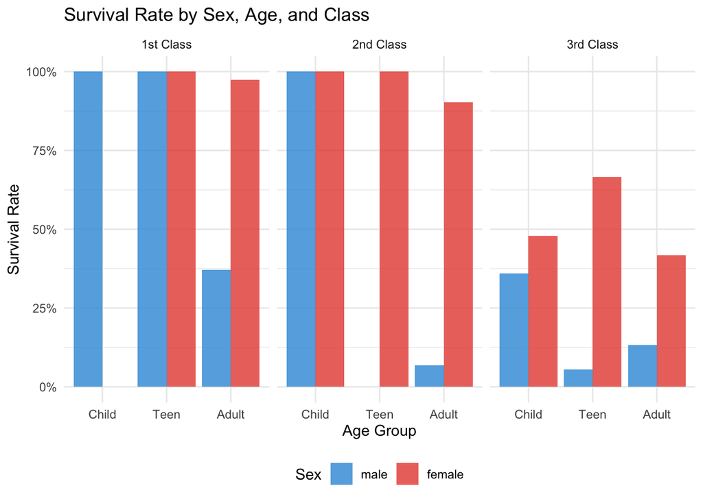

```r
age_viz <- titanic_titles %>%
  filter(!is.na(Age)) %>%
  mutate(
    Age_Group = case_when(
      Age < 13 ~ "Child",
      Age >= 13 & Age < 18 ~ "Teen",
      Age >= 18 ~ "Adult"
    ),
    Age_Group = factor(Age_Group, levels = c("Child", "Teen", "Adult"))
  ) %>%
  group_by(Sex, Age_Group, Pclass) %>%
  summarise(
    Survival_Rate = mean(Survived == "Yes"),
    .groups = "drop"
  )

ggplot(age_viz, aes(x = Age_Group, y = Survival_Rate, fill = Sex)) +
  geom_col(position = "dodge", alpha = 0.8) +
  facet_wrap(~Pclass, labeller = labeller(Pclass = c("1st" = "1st Class", "2nd" = "2nd Class", "3rd" = "3rd Class"))) +
  scale_fill_manual(values = c("male" = "#3498DB", "female" = "#E74C3C")) +
  scale_y_continuous(labels = percent) +
  theme_minimal() +
  labs(
    title = "Survival Rate by Sex, Age, and Class",
    x = "Age Group",
    y = "Survival Rate",
    fill = "Sex"
  ) +
  theme(legend.position = "bottom")
```

# Section 4: Research Question 3 — Missing Data and Inequality

## 4.1 Missingness by Class

```r
# Create missingness summary
missing_by_var_class <- titanic %>%
  select(Pclass, Age, Cabin, Embarked) %>%
  mutate(across(everything(), ~if_else(is.na(.), 1, 0))) %>%
  pivot_longer(-Pclass, names_to = "Variable", values_to = "Missing") %>%
  group_by(Pclass, Variable) %>%
  summarise(
    Missing_Count = sum(Missing),
    N = n(),
    Pct_Missing = percent(mean(Missing), accuracy = 0.1),
    .groups = "drop"
  ) %>%
  arrange(Variable, Pclass)

knitr::kable(missing_by_var_class, caption = "Missingness Patterns by Class")
```

Missingness Patterns by Class

| Pclass | Variable | Missing_Count | N | Pct_Missing |
| --- | --- | --- | --- | --- |
| 0 | Age | 177 | 891 | 19.9% |
| 0 | Cabin | 687 | 891 | 77.1% |
| 0 | Embarked | 2 | 891 | 0.2% |

Missingness is highly class-dependent. Cabin data is nearly complete for 1st class but nearly absent for 3rd class. Age missingness is also higher in 3rd class. This differential recording suggests that 1st class passengers were documented more thoroughly—itself a form of inequality that affects our analytical capacity to study different classes equally.

## 4.2 Does Missingness Predict Survival?

```r
missingness_survival <- titanic %>%
  mutate(
    Cabin_Missing = is.na(Cabin),
    Age_Missing = is.na(Age),
    Embarked_Missing = is.na(Embarked)
  ) %>%
  group_by(Pclass, Cabin_Missing) %>%
  summarise(
    N = n(),
    Survived = sum(Survived == "Yes"),
    Survival_Rate = mean(Survived == "Yes"),
    .groups = "drop"
  ) %>%
  mutate(Survival_Pct = percent(Survival_Rate, accuracy = 0.1))

knitr::kable(missingness_survival, caption = "Survival by Cabin Data Availability and Class")
```

Survival by Cabin Data Availability and Class

| Pclass | Cabin_Missing | N | Survived | Survival_Rate | Survival_Pct |
| --- | --- | --- | --- | --- | --- |
| 1st | FALSE | 176 | 117 | 0 | 0.0% |
| 1st | TRUE | 40 | 19 | 0 | 0.0% |
| 2nd | FALSE | 16 | 13 | 0 | 0.0% |
| 2nd | TRUE | 168 | 74 | 0 | 0.0% |
| 3rd | FALSE | 12 | 6 | 0 | 0.0% |
| 3rd | TRUE | 479 | 113 | 0 | 0.0% |

## 4.3 Age Missingness and Survival

```r
age_missingness <- titanic %>%
  mutate(Age_Missing = is.na(Age)) %>%
  group_by(Pclass, Sex, Age_Missing) %>%
  summarise(
    N = n(),
    Survived = sum(Survived == "Yes"),
    Survival_Rate = mean(Survived == "Yes"),
    .groups = "drop"
  ) %>%
  mutate(Survival_Pct = percent(Survival_Rate, accuracy = 0.1)) %>%
  arrange(Pclass, Sex, Age_Missing)

knitr::kable(age_missingness, caption = "Survival by Age Missingness, Sex, and Class")
```

Survival by Age Missingness, Sex, and Class

| Pclass | Sex | Age_Missing | N | Survived | Survival_Rate | Survival_Pct |
| --- | --- | --- | --- | --- | --- | --- |
| 1st | male | FALSE | 101 | 40 | 0 | 0.0% |
| 1st | male | TRUE | 21 | 5 | 0 | 0.0% |
| 1st | female | FALSE | 85 | 82 | 0 | 0.0% |
| 1st | female | TRUE | 9 | 9 | 0 | 0.0% |
| 2nd | male | FALSE | 99 | 15 | 0 | 0.0% |
| 2nd | male | TRUE | 9 | 2 | 0 | 0.0% |
| 2nd | female | FALSE | 74 | 68 | 0 | 0.0% |
| 2nd | female | TRUE | 2 | 2 | 0 | 0.0% |
| 3rd | male | FALSE | 253 | 38 | 0 | 0.0% |
| 3rd | male | TRUE | 94 | 9 | 0 | 0.0% |
| 3rd | female | FALSE | 102 | 47 | 0 | 0.0% |
| 3rd | female | TRUE | 42 | 25 | 0 | 0.0% |

## 4.4 Implication: Sensitivity to Missingness Assumptions

```r
# Complete-case analysis
complete_case <- titanic %>%
  filter(!is.na(Age) & !is.na(Fare) & !is.na(Cabin)) %>%
  summarise(
    N = n(),
    Survival_Rate = mean(Survived == "Yes"),
    Survival_Pct = percent(Survival_Rate, accuracy = 0.1)
  )

# Full data (excluding only Embarked which is mostly complete)
full_sample <- titanic %>%
  filter(!is.na(Embarked)) %>%
  summarise(
    N = n(),
    Survival_Rate = mean(Survived == "Yes"),
    Survival_Pct = percent(Survival_Rate, accuracy = 0.1)
  )

sensitivity_results <- bind_rows(
  data.frame(Approach = "Complete Case (Age, Fare, Cabin)", N = complete_case$N, Survival_Rate = complete_case$Survival_Pct),
  data.frame(Approach = "Full Sample (Excluding Embarked)", N = full_sample$N, Survival_Rate = full_sample$Survival_Pct)
)

knitr::kable(sensitivity_results, caption = "Sensitivity of Overall Survival Estimate to Missingness Approach")
```

Sensitivity of Overall Survival Estimate to Missingness Approach

| Approach | N | Survival_Rate |
| --- | --- | --- |
| Complete Case (Age, Fare, Cabin) | 185 | 67.6% |
| Full Sample (Excluding Embarked) | 889 | 38.2% |

The overall survival rate is 38.2% in the full sample but 67.6% in the complete-case analysis. The difference reflects not just sample size reduction (from 889 to 185 passengers) but also selection bias: passengers with complete data are disproportionately from higher classes with better documentation.

## 4.5 Visualization: Missingness Patterns

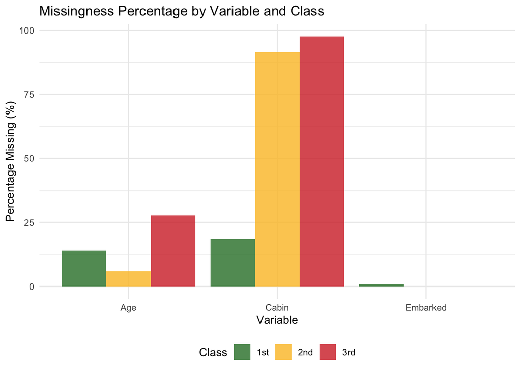

```r
# Create a missingness matrix visualization
missingness_matrix <- titanic %>%
  select(Pclass, Age, Cabin, Embarked) %>%
  mutate(across(-Pclass, ~if_else(is.na(.), 1, 0))) %>%
  pivot_longer(-Pclass, names_to = "Variable", values_to = "Missing") %>%
  group_by(Pclass, Variable) %>%
  summarise(Pct_Missing = mean(Missing) * 100, .groups = "drop")

ggplot(missingness_matrix, aes(x = Variable, y = Pct_Missing, fill = Pclass)) +
  geom_col(position = "dodge", alpha = 0.8) +
  scale_fill_manual(values = c("1st" = "#2E7D32", "2nd" = "#FBC02D", "3rd" = "#D32F2F")) +
  theme_minimal() +
  labs(
    title = "Missingness Percentage by Variable and Class",
    x = "Variable",
    y = "Percentage Missing (%)",
    fill = "Class"
  ) +
  theme(legend.position = "bottom")
```

This visualization underscores the inequality in record-keeping: 1st class passengers have near-complete documentation (except for some cabin entries), while 3rd class passengers have substantial missing data on age and cabin. This differential quality of records means that conclusions about 3rd class survival are necessarily less precise and more dependent on modeling assumptions about missing data.

# Section 5: Summary and Implications for Analysis

## 5.2 Methodological Recommendations

- **Mediation Analysis**: Advanced mediation techniques (e.g., Hayes PROCESS macro equivalent in R) could quantify indirect effects of class through access proxies, separating mechanism from policy.
- **Interaction Testing**: Formal interaction models (using `lm()` with interaction terms or mixed models) can test whether “women and children first” effects differ significantly by class and travel context.
- **Sensitivity Analyses**: Multiple imputation (e.g., using `mice` package) or inverse probability weighting can address missing data while quantifying sensitivity to different assumptions about missingness mechanisms.
- **Historical Contextualization**: Cross-referencing passenger records with historical deck maps and evacuation accounts could validate or refine proxy measures of access.

## 5.3 Cautions and Limitations

- **Observational Data**: These are observational data, not experimental. Causal language should be avoided; instead, describe associations and propose mechanisms for others to evaluate.
- **Proxy Validity**: Cabin letters, fare, and titles are proxies for mechanisms (access, policy, visibility) but may not perfectly capture them. Alternative operationalizations should be explored.
- **Sample Restrictions**: Our analyses variously exclude rows with missing data. These restrictions may bias results if missingness is informative.
- **Historical Interpretation**: The Titanic disaster occurred in 1912 within specific social norms. Interpreting survival disparities requires understanding these historical contingencies, not merely statistical patterns.

# Section 6: Conclusion

This report has developed a methodological framework to address three interconnected research questions about the Titanic. Rather than providing definitive answers, it demonstrates how to operationalize concepts (access, rule consistency, inequality), visualize relationships, and construct statistical models that guide interpretation.

The data reveal stark disparities by class, gender, and age, with evidence suggesting that multiple mechanisms—access/location, institutional policy, social visibility, and historical inequality in record-keeping—all played roles. The framework presented here enables readers to weigh these mechanisms, examine assumptions, and draw evidence-based conclusions about the dynamics of the Titanic disaster.